# Importation

# Chargement et manipulation des données

## Data-frame et facteurs

```r
data("mtcars")
mtcars
```

|  | mpg | cyl | disp | hp | drat | wt | qsec | vs | am | gear | carb |
| --- | --- | --- | --- | --- | --- | --- | --- | --- | --- | --- | --- |
| Mazda RX4 | 21.0 | 6 | 160.0 | 110 | 3.90 | 2.620 | 16.46 | 0 | 1 | 4 | 4 |
| Mazda RX4 Wag | 21.0 | 6 | 160.0 | 110 | 3.90 | 2.875 | 17.02 | 0 | 1 | 4 | 4 |
| Datsun 710 | 22.8 | 4 | 108.0 | 93 | 3.85 | 2.320 | 18.61 | 1 | 1 | 4 | 1 |
| Hornet 4 Drive | 21.4 | 6 | 258.0 | 110 | 3.08 | 3.215 | 19.44 | 1 | 0 | 3 | 1 |
| Hornet Sportabout | 18.7 | 8 | 360.0 | 175 | 3.15 | 3.440 | 17.02 | 0 | 0 | 3 | 2 |
| Valiant | 18.1 | 6 | 225.0 | 105 | 2.76 | 3.460 | 20.22 | 1 | 0 | 3 | 1 |
| Duster 360 | 14.3 | 8 | 360.0 | 245 | 3.21 | 3.570 | 15.84 | 0 | 0 | 3 | 4 |
| Merc 240D | 24.4 | 4 | 146.7 | 62 | 3.69 | 3.190 | 20.00 | 1 | 0 | 4 | 2 |
| Merc 230 | 22.8 | 4 | 140.8 | 95 | 3.92 | 3.150 | 22.90 | 1 | 0 | 4 | 2 |
| Merc 280 | 19.2 | 6 | 167.6 | 123 | 3.92 | 3.440 | 18.30 | 1 | 0 | 4 | 4 |

[output cut: 22 more lines]

Ce jeu de données est-il une matrice (**is.matrix**) ? Un data.frame (**is.data.frame**) ? Une liste ?

```r
is.matrix(mtcars)
```

```
## [1] FALSE
```

```r
is.list(mtcars)
```

```
## [1] TRUE
```

```r
is.data.frame(mtcars)
```

```
## [1] TRUE
```

Quelle est sa dimension ?

```r
dim(mtcars)
```

```
## [1] 32 11
```

Combien de variables contient-il ? Quel est leur nom (**names**) ?

```r
paste(ncol(mtcars), 'variables', sep = " ")
```

```
## [1] "11 variables"
```

```r
names(mtcars)
```

```
##  [1] "mpg"  "cyl"  "disp" "hp"   "drat" "wt"   "qsec" "vs"   "am"   "gear"
## [11] "carb"
```

Décrivez le jeu de données *mtcars*.

```r
help(mtcars) # Voir dans la fenêtre d'aide
```

Donnez le mode de chacune des variables à l’aide de la fonction **summary**.

```r
summary(mtcars)
```

```
##       mpg             cyl             disp             hp
##  Min.   :10.40   Min.   :4.000   Min.   : 71.1   Min.   : 52.0
##  1st Qu.:15.43   1st Qu.:4.000   1st Qu.:120.8   1st Qu.: 96.5
##  Median :19.20   Median :6.000   Median :196.3   Median :123.0
##  Mean   :20.09   Mean   :6.188   Mean   :230.7   Mean   :146.7
##  3rd Qu.:22.80   3rd Qu.:8.000   3rd Qu.:326.0   3rd Qu.:180.0
##  Max.   :33.90   Max.   :8.000   Max.   :472.0   Max.   :335.0
##       drat             wt             qsec             vs
##  Min.   :2.760   Min.   :1.513   Min.   :14.50   Min.   :0.0000
##  1st Qu.:3.080   1st Qu.:2.581   1st Qu.:16.89   1st Qu.:0.0000
##  Median :3.695   Median :3.325   Median :17.71   Median :0.0000
##  Mean   :3.597   Mean   :3.217   Mean   :17.85   Mean   :0.4375
##  3rd Qu.:3.920   3rd Qu.:3.610   3rd Qu.:18.90   3rd Qu.:1.0000
##  Max.   :4.930   Max.   :5.424   Max.   :22.90   Max.   :1.0000
##        am              gear            carb
##  Min.   :0.0000   Min.   :3.000   Min.   :1.000
##  1st Qu.:0.0000   1st Qu.:3.000   1st Qu.:2.000
##  Median :0.0000   Median :4.000   Median :2.000
##  Mean   :0.4062   Mean   :3.688   Mean   :2.812
##  3rd Qu.:1.0000   3rd Qu.:4.000   3rd Qu.:4.000
##  Max.   :1.0000   Max.   :5.000   Max.   :8.000
```

```r
apply(mtcars, 2, mode)
```

```
##       mpg       cyl      disp        hp      drat        wt      qsec
## "numeric" "numeric" "numeric" "numeric" "numeric" "numeric" "numeric"
##        vs        am      gear      carb
## "numeric" "numeric" "numeric" "numeric"
```

Affectez à $x$ la première colonne de *mtcars*, à l’aide du numéro de colonne (**[,i]**) et ensuite du nom de la colonne (**$**).

```r
x <- mtcars[,1]
x <- mtcars$mpg
x
```

```
##  [1] 21.0 21.0 22.8 21.4 18.7 18.1 14.3 24.4 22.8 19.2 17.8 16.4 17.3 15.2
## [15] 10.4 10.4 14.7 32.4 30.4 33.9 21.5 15.5 15.2 13.3 19.2 27.3 26.0 30.4
## [29] 15.8 19.7 15.0 21.4
```

Affichez le 15e, le 3e et le 4e élément de $x$ dans cet ordre.

```r
x[c(15, 3, 4)]
```

```
## [1] 10.4 22.8 21.4
```

Affichez ses 10 premiers éléments. Idem dans l’ordre inverse.

```r
head(x, n=10)
```

```
##  [1] 21.0 21.0 22.8 21.4 18.7 18.1 14.3 24.4 22.8 19.2
```

```r
rev(x[1:10])
```

```
##  [1] 19.2 22.8 24.4 14.3 18.1 18.7 21.4 22.8 21.0 21.0
```

Affichez ses 10 derniers éléments.

```r
tail(x, n=10)
```

```
##  [1] 15.2 13.3 19.2 27.3 26.0 30.4 15.8 19.7 15.0 21.4
```

Transformez la variable Transmission (**am**) en un facteur (*as.factor*). Regardez à nouveau le résumé des données.

```r
mtcars$am <- as.factor(mtcars$am)
summary(mtcars)
```

```
##       mpg             cyl             disp             hp
##  Min.   :10.40   Min.   :4.000   Min.   : 71.1   Min.   : 52.0
##  1st Qu.:15.43   1st Qu.:4.000   1st Qu.:120.8   1st Qu.: 96.5
##  Median :19.20   Median :6.000   Median :196.3   Median :123.0
##  Mean   :20.09   Mean   :6.188   Mean   :230.7   Mean   :146.7
##  3rd Qu.:22.80   3rd Qu.:8.000   3rd Qu.:326.0   3rd Qu.:180.0
##  Max.   :33.90   Max.   :8.000   Max.   :472.0   Max.   :335.0
##       drat             wt             qsec             vs         am
##  Min.   :2.760   Min.   :1.513   Min.   :14.50   Min.   :0.0000   0:19
##  1st Qu.:3.080   1st Qu.:2.581   1st Qu.:16.89   1st Qu.:0.0000   1:13
##  Median :3.695   Median :3.325   Median :17.71   Median :0.0000
##  Mean   :3.597   Mean   :3.217   Mean   :17.85   Mean   :0.4375
##  3rd Qu.:3.920   3rd Qu.:3.610   3rd Qu.:18.90   3rd Qu.:1.0000
##  Max.   :4.930   Max.   :5.424   Max.   :22.90   Max.   :1.0000
##       gear            carb
##  Min.   :3.000   Min.   :1.000
##  1st Qu.:3.000   1st Qu.:2.000
##  Median :4.000   Median :2.000
##  Mean   :3.688   Mean   :2.812
##  3rd Qu.:4.000   3rd Qu.:4.000
##  Max.   :5.000   Max.   :8.000
```

Affectez à $y$ le facteur Transmission.

```r
y <- mtcars$am
```

Créez un nouvel objet constitué de $x$ et $y$.

```r
m <- cbind(x, y)
```

Quel type d’objet a été crée ? Quelle est sa dimension ?

```r
class(m)
```

```
## [1] "matrix"
```

```r
dim(m)
```

```
## [1] 32  2
```

Affichez la 12e ligne de cet objet.

```r
m[12,]
```

```
##    x    y
## 16.4  1.0
```

Affichez les 8 premières lignes de cet objet.

```r
m[1:8,]
```

```
##         x y
## [1,] 21.0 2
## [2,] 21.0 2
## [3,] 22.8 2
## [4,] 21.4 1
## [5,] 18.7 1
## [6,] 18.1 1
## [7,] 14.3 1
## [8,] 24.4 1
```

Affichez la 2e colonne de l’objet.

```r
m[,2]
```

```
##  [1] 2 2 2 1 1 1 1 1 1 1 1 1 1 1 1 1 1 2 2 2 1 1 1 1 1 2 2 2 2 2 2 2
```

```r
m[,1][m[,2]==2]
```

```
##  [1] 21.0 21.0 22.8 32.4 30.4 33.9 27.3 26.0 30.4 15.8 19.7 15.0 21.4
```

Créez un vecteur contenant les consommations moyennes pour les véhicules selon leur type detransmission.

```r
cMoyenne <- by(m[,1], m[,2], mean)
```

Effectuer le même calcul (de consommations moyennes pour les véhicules selon leur type detransmission) sur le data frame **mtcars** et donner les types des objets obtenus : + en utilisant la fonction **subset**. + en utilisant la fonction **by**. *(déjà fait)* + en utilisant la fonction **aggregate**.

```r
aggregate(m[,1], list(m[,2]), mean)
```

| Group.1 | x |
| --- | --- |
| 1 | 17.14737 |
| 2 | 24.39231 |

```r
c(mean(subset(m[,1], m[,2]==1)), mean(subset(m[,1], m[,2]==2)))
```

```
## [1] 17.14737 24.39231
```

Créez un vecteur contenant les écarts types associés au consommations moyennes des véhicules en fonction de leur type de transmission.

```r
cEcartType <- by(m[,1], m[,2], sd)
```

Résumez les informations obtenues sur la consommation.

```r
as.list(as.data.frame(cbind(cMoyenne,cEcartType)))
```

```
## $cMoyenne
## [1] 17.14737 24.39231
##
## $cEcartType
## [1] 3.833966 6.166504
```

# Chargement de jeux de données externes.

## Importation simple.

Importez le jeu de données **cancerprostate**.

```r
cancerprostate <- read.table("donnees/cancerprostate.txt", header=T,sep=";")
str(cancerprostate)
```

```
## 'data.frame':    53 obs. of  7 variables:
##  $ age     : int  66 68 66 56 58 60 65 60 50 49 ...
##  $ acide   : num  0.48 0.56 0.5 0.52 0.5 0.49 0.46 0.62 0.56 0.55 ...
##  $ rayonx  : int  0 0 0 0 0 0 1 1 0 1 ...
##  $ taille  : int  0 0 0 0 0 0 0 0 0 0 ...
##  $ grade   : int  0 0 0 0 0 0 0 0 1 0 ...
##  $ Y       : int  0 0 0 0 0 0 0 0 1 0 ...
##  $ log.acid: num  -0.734 -0.58 -0.693 -0.654 -0.693 ...
```

Modifier votre importation afin que les variables soient d’un mode approprié.

```r
cancerprostate <- read.table("donnees/cancerprostate.txt", header=T, sep=";",
                             colClasses = c("integer","numeric","factor","factor","factor","factor","numeric"))
str(cancerprostate)
```

```
## 'data.frame':    53 obs. of  7 variables:
##  $ age     : int  66 68 66 56 58 60 65 60 50 49 ...
##  $ acide   : num  0.48 0.56 0.5 0.52 0.5 0.49 0.46 0.62 0.56 0.55 ...
##  $ rayonx  : Factor w/ 2 levels "0","1": 1 1 1 1 1 1 2 2 1 2 ...
##  $ taille  : Factor w/ 2 levels "0","1": 1 1 1 1 1 1 1 1 1 1 ...
##  $ grade   : Factor w/ 2 levels "0","1": 1 1 1 1 1 1 1 1 2 1 ...
##  $ Y       : Factor w/ 2 levels "0","1": 1 1 1 1 1 1 1 1 2 1 ...
##  $ log.acid: num  -0.734 -0.58 -0.693 -0.654 -0.693 ...
```

Impotez le jeu de données **test1**.

```r
test1 <- read.table("donnees/test1.csv", header=T, sep=",")
names(test1)
```

```
## [1] "CLONE" "B"     "IN"    "HT19"  "C19"   "HT29"  "X"     "X.1"
```

Les deux dernières colonnes n’avaient pas de libellés, remplacés par “X” et “X.1”.  
Importez le jeu de données **test2**. Y a-t-il de données manquantes ? Si oui, combien ?

```r
test2 <- read.table("donnees/test2.csv", header=T, sep=",")
sum(is.na(test2))
```

```
## [1] 50
```

Extraire le data frame ne contenant pas de données manquantes.

```r
test2 <- na.omit(test2)
```

## Fusion de jeux de données

Les données d’intérêts peuvent parfois être contenues dans plusieurs jeux de données séparés.

Importez les jeux de données **etat1** et **etat2**.

```r
etat1 <- read.table("donnees/etat1.csv", header = T, sep = ";")
etat2 <- read.table("donnees/etat2.csv", header = T, sep = ",")
```

Les dimensions des jeux de données.

```r
c(dim(etat1), dim(etat2))
```

```
## [1] 50  2 50  9
```

Fusion avec **cbind()**.

```r
cbind(etat1, etat2)
```

| region | etat | etat | Population | Income | Illiteracy | Life.Exp | Murder | HS.Grad | Frost | Area |
| --- | --- | --- | --- | --- | --- | --- | --- | --- | --- | --- |
| South | Alabama | Alabama | 3615 | 3624 | 2.1 | 69.05 | 15.1 | 41.3 | 20 | 50708 |
| West | Alaska | Alaska | 365 | 6315 | 1.5 | 69.31 | 11.3 | 66.7 | 152 | 566432 |
| West | Arizona | Arizona | 2212 | 4530 | 1.8 | 70.55 | 7.8 | 58.1 | 15 | 113417 |
| South | Arkansas | Arkansas | 2110 | 3378 | 1.9 | 70.66 | 10.1 | 39.9 | 65 | 51945 |
| West | California | California | 21198 | 5114 | 1.1 | 71.71 | 10.3 | 62.6 | 20 | 156361 |
| West | Colorado | Colorado | 2541 | 4884 | 0.7 | 72.06 | 6.8 | 63.9 | 166 | 103766 |
| Northeast | Connecticut | Connecticut | 3100 | 5348 | 1.1 | 72.48 | 3.1 | 56.0 | 139 | 4862 |
| South | Delaware | Delaware | 579 | 4809 | 0.9 | 70.06 | 6.2 | 54.6 | 103 | 1982 |
| South | Florida | Florida | 8277 | 4815 | 1.3 | 70.66 | 10.7 | 52.6 | 11 | 54090 |
| South | Georgia | Georgia | 4931 | 4091 | 2.0 | 68.54 | 13.9 | 40.6 | 60 | 58073 |

[output cut: 40 more lines]

Fusion avec **merge()**.

```r
etat <- merge(etat1, etat2) #  ,by = "etat"
```

**merge()** est plus approprié en fusionnant les données de mêmes individus.  
Que se passe-t-il si les individus diffèrent entre les 2 jeux de données ?

```r
etat2$etat[1] <- NA # Alabama
merge(etat1, etat2)
```

| etat | region | Population | Income | Illiteracy | Life.Exp | Murder | HS.Grad | Frost | Area |
| --- | --- | --- | --- | --- | --- | --- | --- | --- | --- |
| Alaska | West | 365 | 6315 | 1.5 | 69.31 | 11.3 | 66.7 | 152 | 566432 |
| Arizona | West | 2212 | 4530 | 1.8 | 70.55 | 7.8 | 58.1 | 15 | 113417 |
| Arkansas | South | 2110 | 3378 | 1.9 | 70.66 | 10.1 | 39.9 | 65 | 51945 |
| California | West | 21198 | 5114 | 1.1 | 71.71 | 10.3 | 62.6 | 20 | 156361 |
| Colorado | West | 2541 | 4884 | 0.7 | 72.06 | 6.8 | 63.9 | 166 | 103766 |
| Connecticut | Northeast | 3100 | 5348 | 1.1 | 72.48 | 3.1 | 56.0 | 139 | 4862 |
| Delaware | South | 579 | 4809 | 0.9 | 70.06 | 6.2 | 54.6 | 103 | 1982 |
| Florida | South | 8277 | 4815 | 1.3 | 70.66 | 10.7 | 52.6 | 11 | 54090 |
| Georgia | South | 4931 | 4091 | 2.0 | 68.54 | 13.9 | 40.6 | 60 | 58073 |
| Hawaii | West | 868 | 4963 | 1.9 | 73.60 | 6.2 | 61.9 | 0 | 6425 |

[output cut: 39 more lines]

La ligne avec *Alabama* ne figure pas dans la fusion.

Création et manipulation de facteurs.  
À l’aide de la fonction **cut**, créez un facteur **Richesse** séparant les états selon leur revenu moyen (**Income**) : Pauvre (inférieur ou égal à 4000), Aisé (entre 4001 et 5000) et Riche(supérieurs ou égal à 5001). Vérifiez si le résultat contient des *NA*.

```r
Richesse <- cut(etat$Income, breaks = c(0, 4000, 5000, Inf),
                include.lowest = T, labels = c("Pauvre", "Aisé", "Riche"))

sum(is.na(Richesse))
```

```
## [1] 0
```

Effectuez le découpage de la variable **Income** cette fois-ci en 5 niveaux d’effectifs comparables(utilisez la fonction **quantile**).

```r
etat$income <- cut(etat$Income, breaks = quantile(etat$Income, probs=c(0:5/5)),
                   include.lowest = T, labels = c("R1", "R2", "R3", "R4", "R5"))
```

Pour fusionneR deux niveaux d’un vecteur (en cas de groupes à effectifs trop faibles parexemple), on peut renommer les niveaux des 2 classes à fusionner avec le même nom. Fusionnez les classes *R1* et *R2* ainsi que les classes *R3* et *R4* dans l’exemple.

```r
levels(etat$income) <- c("R1", "R1", "R3", "R3", "R5")
```

## Variables au format Date

Importez le jeu de données **bladder**. Décrivez brièvement ce dernier.

```r
bladder <- read.table("donnees/bladder.txt", header=F, sep = "\t")
```

Contient-il des données manquantes ?  
La dernière colonne est complètement vide, donc les 57 lignes contiennent au moins une donnée vide.

```r
sum(is.na(bladder))
```

```
## [1] 57
```

Prenez quelques variables au hasard et effectuez leur résumé et un boxplot de leurs valeurs (fonction graphique **boxplot**). Que remarquez-vous ?

```r
summary(bladder[,1:3])
```

```
##        V1                  V2                  V3
##  Min.   :-500.0000   Min.   :-500.0000   Min.   :-500.0000
##  1st Qu.:  -0.2253   1st Qu.:  -0.0444   1st Qu.:   0.0580
##  Median :  -0.1390   Median :   0.0003   Median :   0.0932
##  Mean   : -17.6413   Mean   :  -8.7445   Mean   :  -8.6733
##  3rd Qu.:  -0.0639   3rd Qu.:   0.0847   3rd Qu.:   0.1193
##  Max.   :   0.3432   Max.   :   0.4179   Max.   :   0.5606
```

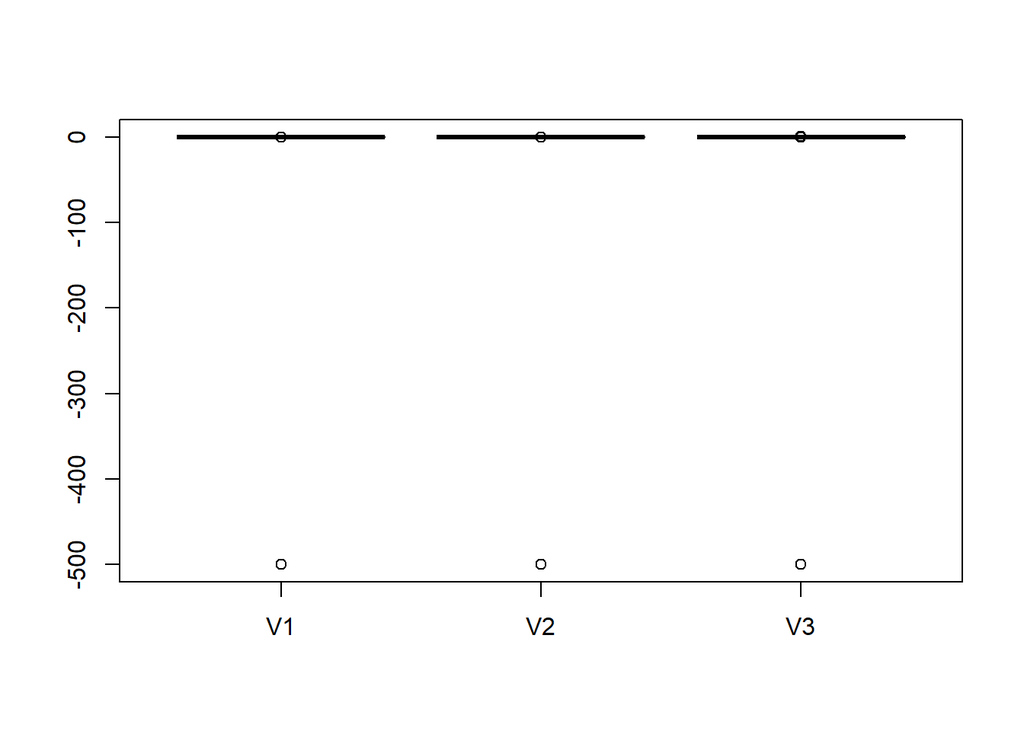

```r
boxplot(bladder[,1:3])
```

On a pris les 3 premières valables. On remarque d’après le résumé et les boxplot que les données se concentrent autour de 0 (Max et Med) avec des valeurs abérantes où Min = -500.

Importez de nouveau le jeu de données en spécifiant les valeurs à considérer comme données manquantes **NA**.

```r
bladder <- read.table("donnees/bladder.txt", header = F, sep = "\t", na.strings = -500)
```

Remplacer les données manquantes par la moyenne de la variable en question.

```r
bladder <- apply(bladder, 2, FUN=function(x){replace(x, is.na(x), mean(x, na.rm=TRUE) )})
```